# Applying Machine Learning Algorithms to Determine Credit-Worthiness

## Bagging

The next method used is called bagging. Bagging is used to reduce the high variance of a single tree. It generates many trees and averages them out for the prediction on the response. First, we generate different training datasets by taking repeated samples and then for each training dataset, we estimate the response. Then finally, we average these predictions to get the estimation of the response for each record.

```r
set.seed(2)
library(randomForest)
credit.bag = randomForest(class~.,data=credit,subset=train,mtry=20,importance=TRUE) #model
credit.bag
```

```
##
## Call:
##  randomForest(formula = class ~ ., data = credit, mtry = 20, importance = TRUE,      subset = train)
##                Type of random forest: classification
##                      Number of trees: 500
## No. of variables tried at each split: 20
##
##         OOB estimate of  error rate: 25.71%
## Confusion matrix:
##     0  1 class.error
## 0 426 66   0.1341463
## 1 114 94   0.5480769
```

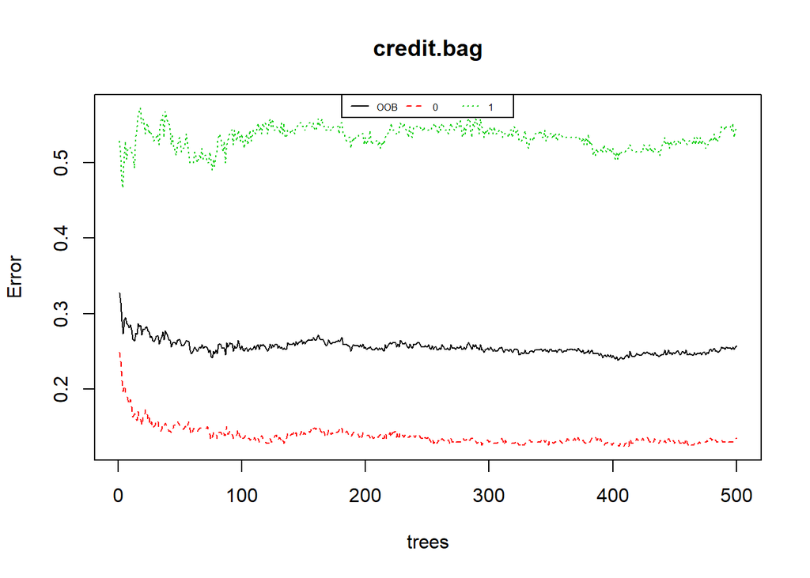

```r
#Error plot
plot(credit.bag)
credit.bag.legend <- if (is.null(credit.bag$test$err.rate)){colnames(credit.bag$err.rate)} else {colnames(credit.bag$test$err.rate)}
legend("top", cex =0.5, legend=credit.bag.legend, lty=c(1,2,3), col=c(1,2,3), horiz=T)
```

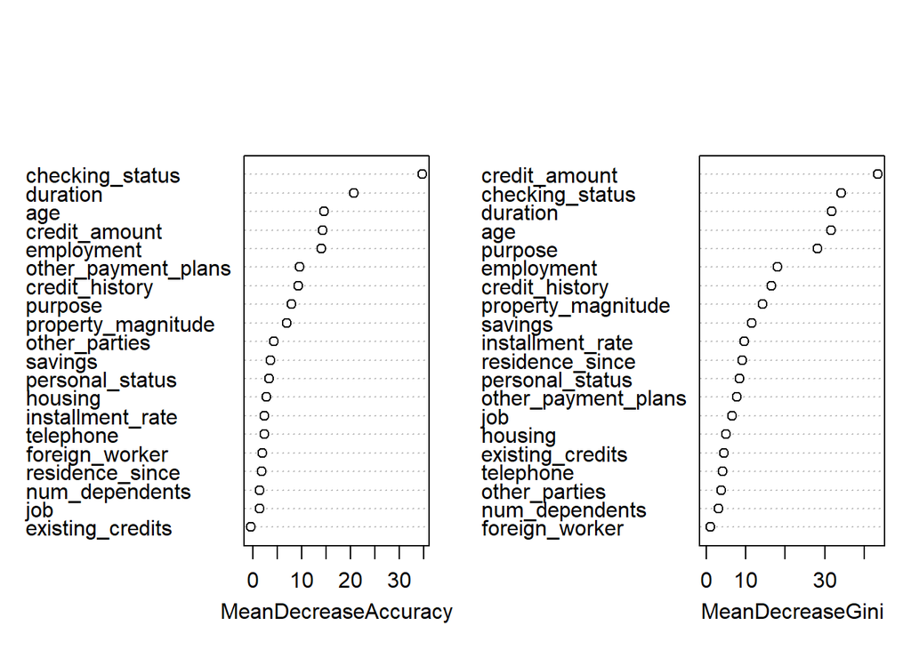

```r
#Variable importance
varImpPlot(credit.bag,main="") #use importance(credit.bag) to view the values
```

```r
bag.pred = predict(credit.bag,newdata=credit.test)
table(bag.pred,class.test) #confustion matrix
```

```
##         class.test
## bag.pred   0   1
##        0 181  45
##        1  27  47
```

```r
CM = table(bag.pred,class.test) #save confusion matrix to variable CM
bagging_pa <- (sum(diag(CM)))/sum(CM) #prediction accuracy
```

By setting mtry=20 means we are using all of the predictors which means we are using the bagging method. The prediction accuracy rate given by this model is 76%. The plot is an error plot with the x-axis as the number of trees and the y-axis as the error rate. As you can see, as the number of trees increases, the error rate decreases. The black plot is the overall Out-of-Bag error rate, the red is the class 0 error rate, and the green is the class 1 error rate. The importance of predictors are given in the next plot. The variables credit_amount, checking_status, duration, age, and purpose are all very importance predictors because they are shown at the very top of the second dot-plot. The importance is determined by the Gini index for classification trees. These predictors were mentioned before in the descriptive analysis part and proves that they are indeed important predictors.

By default, it creates 500 trees which is one of the issues with bagging. They are hard to interpret. So let’s see how the model changes if we only change the parameter ntree (number of trees).

```r
set.seed(2)
credit.bag = randomForest(class~.,data=credit,subset=train,mtry=20,ntree=200) #200 trees
credit.bag
```

```
##
## Call:
##  randomForest(formula = class ~ ., data = credit, mtry = 20, ntree = 200,      subset = train)
##                Type of random forest: classification
##                      Number of trees: 200
## No. of variables tried at each split: 20
##
##         OOB estimate of  error rate: 23.86%
## Confusion matrix:
##     0  1 class.error
## 0 435 57   0.1158537
## 1 110 98   0.5288462
```

```r
bag.pred = predict(credit.bag,newdata=credit.test)
table(bag.pred,class.test)
```

```
##         class.test
## bag.pred   0   1
##        0 179  47
##        1  29  45
```

```r
table(bag.pred,class.test) #confusion matrix
```

```
##         class.test
## bag.pred   0   1
##        0 179  47
##        1  29  45
```

```r
CM = table(bag.pred,class.test)
(sum(diag(CM)))/sum(CM) #prediction accuracy
```

```
## [1] 0.7466667
```

I ran the model using different values for the number of trees less than 500 and no matter which value I set ntree equal to, I get a lower prediction accuracy than the model before using 500 trees. Although, the OOB error slightly improved.

## Random Forest

```r
set.seed(2)
credit.rf = randomForest(class~.,data=credit,subset=train,mtry=5,importance=TRUE)
credit.rf
```

```
##
## Call:
##  randomForest(formula = class ~ ., data = credit, mtry = 5, importance = TRUE,      subset = train)
##                Type of random forest: classification
##                      Number of trees: 500
## No. of variables tried at each split: 5
##
##         OOB estimate of  error rate: 24.57%
## Confusion matrix:
##     0  1 class.error
## 0 452 40  0.08130081
## 1 132 76  0.63461538
```

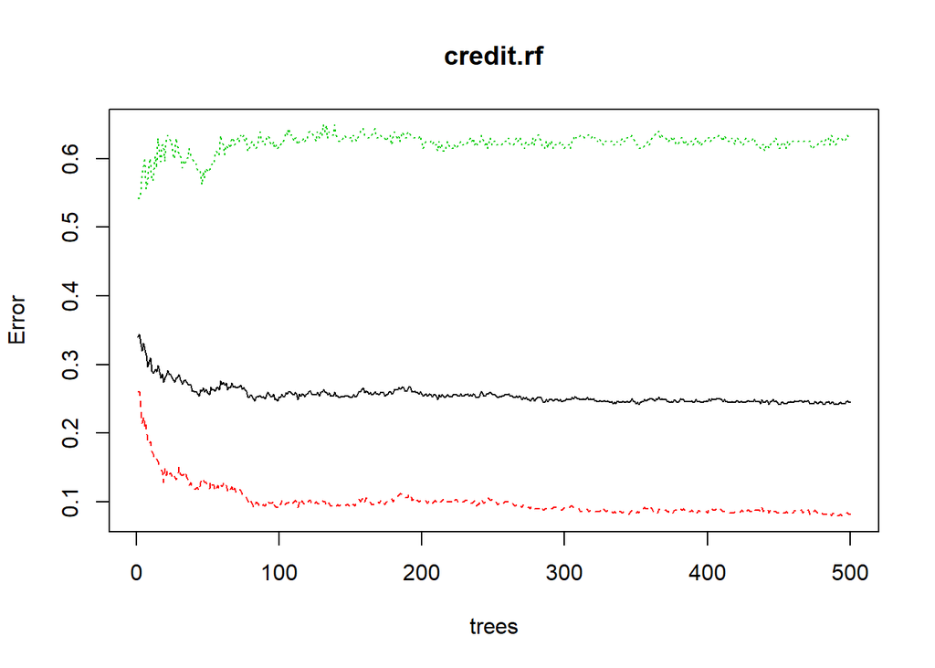

```r
plot(credit.rf)
```

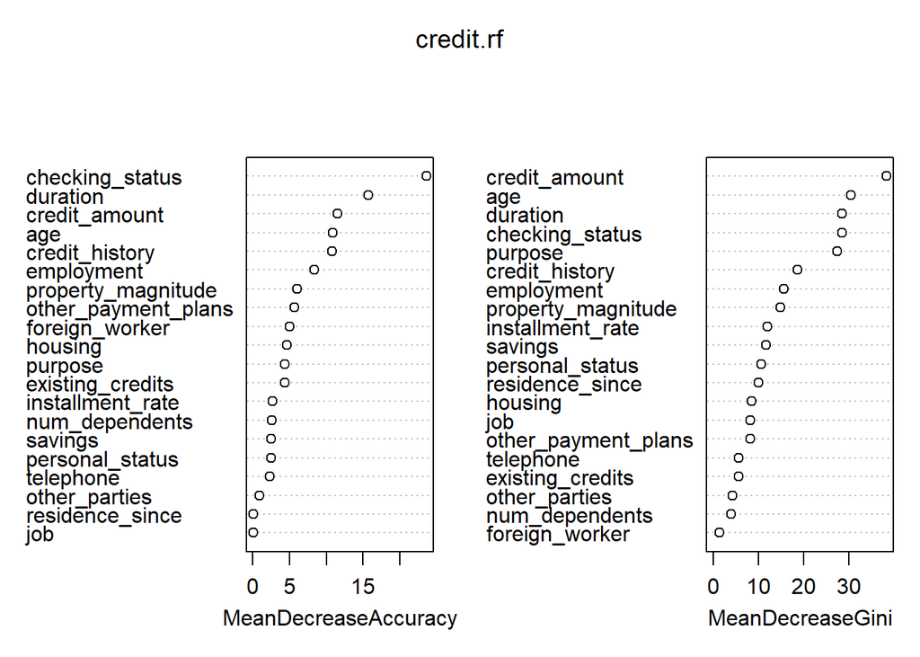

```r
varImpPlot(credit.rf)
```

```r
rf.pred = predict(credit.rf,newdata=credit.test)
table(rf.pred,class.test) #confusion matrix
```

```
##        class.test
## rf.pred   0   1
##       0 188  55
##       1  20  37
```

```r
CM = table(rf.pred,class.test)
rf_pa <- (sum(diag(CM)))/sum(CM) #prediction accuracy rate
```

## Conclusion

There were 6 models that were obtained in this analysis using different methods: logistic regression, logistic regression with LASSO, decision tree before pruning, decision tree with pruning, bagging, and random forest. Of course, results from these models all vary by setting different parameters as shown. Here is a table summarizing the results obtained from each model.

```r
model.summary <- data.frame("Method"=c("Logistic Regression","Logistic Regression with LASSO","Decision Tree Before Pruning (7 Terminal Nodes)","Decision Tree with Pruning (5 Terminal Nodes)","Bagging","Random Forest"),
                            "Prediction Accuracy"=c(logreg_pa, logreg_lasso_pa, dt_pa, dt_5_pa, bagging_pa, rf_pa))
model.summary
```

[output not shown]